# Full-Code-version

```python
# import libraries for data manipulation
import numpy as np
import pandas as pd

# import libraries for data visualization
import matplotlib.pyplot as plt
import seaborn as sns
```

```python
# uncomment and run the below code snippets if the dataset is present in the Google Drive
from google.colab import drive
drive.mount('/content/drive')
```

```python
# Write your code here to read the data
file_path = '/content/drive/My Drive/Python Course/foodhub_order.csv'
df = pd.read_csv(file_path)

# Write your code here to view the first 5 rows
df.head(5)
```

|  | order_id | customer_id | restaurant_name | cuisine_type | cost_of_the_order | day_of_the_week | rating | food_preparation_time | delivery_time |
| --- | --- | --- | --- | --- | --- | --- | --- | --- | --- |
| 0 | 1477147 | 337525 | Hangawi | Korean | 30.75 | Weekend | Not given | 25 | 20 |
| 1 | 1477685 | 358141 | Blue Ribbon Sushi Izakaya | Japanese | 12.08 | Weekend | Not given | 25 | 23 |
| 2 | 1477070 | 66393 | Cafe Habana | Mexican | 12.23 | Weekday | 5 | 23 | 28 |
| 3 | 1477334 | 106968 | Blue Ribbon Fried Chicken | American | 29.20 | Weekend | 3 | 25 | 15 |
| 4 | 1478249 | 76942 | Dirty Bird to Go | American | 11.59 | Weekday | 4 | 25 | 24 |

### **Question 1:** How many rows and columns are present in the data? [0.5 mark]

```python
# Write your code here
df.info()
```

[output not shown]

#### Observations: there are a total of 9 columns and 1898 rows

### **Question 2:** What are the datatypes of the different columns in the dataset? (The info() function can be used) [0.5 mark]

```python
# Write your code here
df.info()
```

[output not shown]

#### Observations:

#### order_id,customer_id,food_preparation_time,delivery_time have datatype of int64

#### cost_of_the_order has data type of float64

#### restaurant_name , cuisine_type , day_of_the_week, rating have data type of object

### **Question 3:** Are there any missing values in the data? If yes, treat them using an appropriate method. [1 mark]

```python
# Write your code here
#df.info()

print('sum of all missing values', df.isnull().sum(), '\n')

print('\n order_id null count ', df['order_id'].isnull().sum())
print('customer_id null count ', df['customer_id'].isnull().sum())
print('restaurant_name ',df['restaurant_name'].isnull().sum())
print('cuisine_type null count ', df['cuisine_type'].isnull().sum())
print('cost_of_the_order null count ', df['cost_of_the_order'].isnull().sum())
print('day_of_the_week null count ', df['day_of_the_week'].isnull().sum())
print('rating null count ', df['rating'].isnull().sum())
print('food_preparation_time null count ', df['food_preparation_time'].isnull().sum())
print('delivery_time null count ', df['delivery_time'].isnull().sum())
```

[output not shown]

#### Observations: there are no columns with missing value cell.

### **Question 4:** Check the statistical summary of the data. What is the minimum, average, and maximum time it takes for food to be prepared once an order is placed? [2 marks]

```python
# Write your code here
#df.head()
print('average time it takes to prepare food : ',df['food_preparation_time'].mean())
print('maximum time it takes to prepare food : ',df['food_preparation_time'].max())
print('minimum time it takes to prepare food : ', df['food_preparation_time'].min())

# we can also do describe
df['food_preparation_time'].describe()
```

[output not shown]

#### Observations:

##### average time it takes to prepare food : 27.371970495258168

##### maximum time it takes to prepare food : 35

##### minimum time it takes to prepare food : 20

### **Question 5:** How many orders are not rated? [1 mark]

```python
# Write your code here
#df.head()
#print(df['rating'].isnull().sum())
#df['rating'].unique()
not_rated = df[df['rating'] == 'Not given']
print('number of orders that are not rated : ', len(not_rated))
```

```
number of orders that are not rated :  736
```

#### Observations: there are 736 orders that are not rated

### **Question 6:** Explore all the variables and provide observations on their distributions. (Generally, histograms, boxplots, countplots, etc. are used for univariate exploration.) [9 marks]

[output not shown]

[output cut: 28 more lines]

[output not shown]

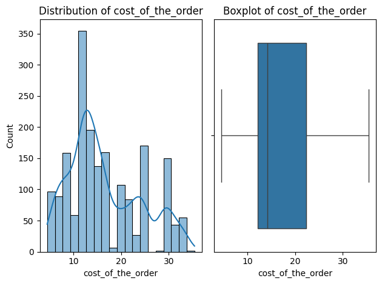

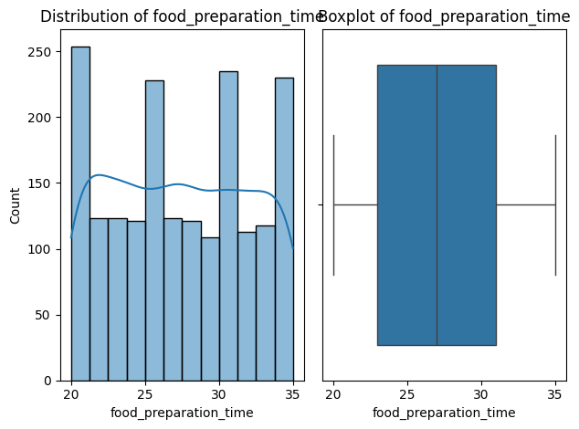

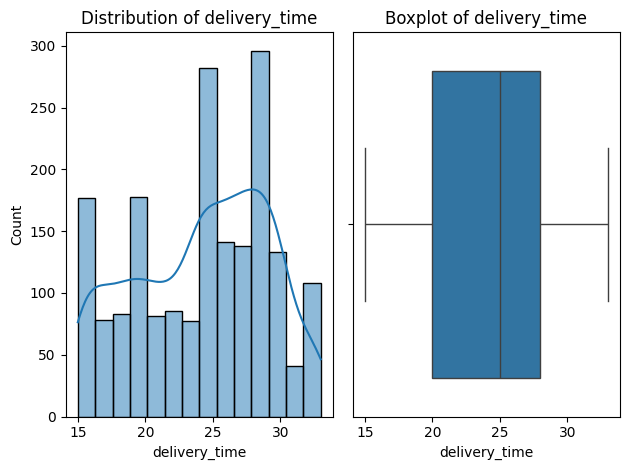

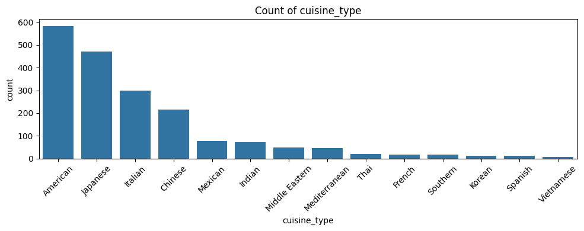

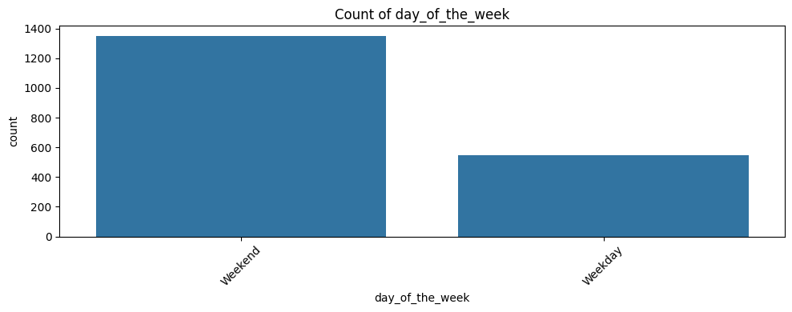

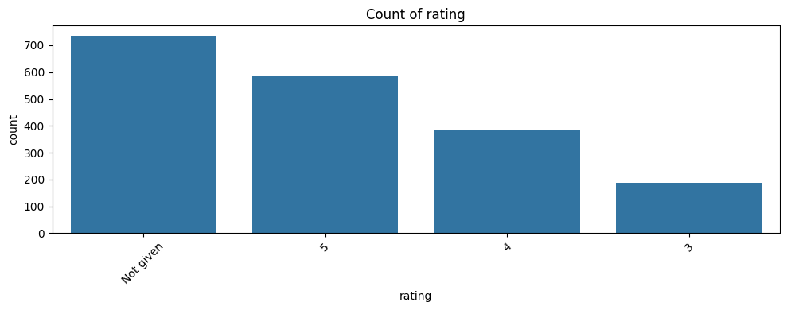

```python
# Write the code here
print('unique order_id', df['order_id'].unique())
print('unique customer_id', df['customer_id'].unique())
print('unique restaurant_name', df['restaurant_name'].unique())
print('unique cuisine_type', df['cuisine_type'].unique())
print('unique day_of_the_week', df['day_of_the_week'].unique())
print('unique rating', df['rating'].unique())
print('unique food_preparation_time', df['food_preparation_time'].unique())
print('unique delivery_time', df['delivery_time'].unique())
print('unique cost_of_the_order', df['cost_of_the_order'].unique())


# 1. Numerical Features
numerical_cols = ['cost_of_the_order', 'food_preparation_time', 'delivery_time']

for col in numerical_cols:
    fig, axes = plt.subplots(1, 2)

    sns.histplot(df[col], kde=True, ax=axes[0])
    axes[0].set_title(f'Distribution of {col}')

    sns.boxplot(x=df[col], ax=axes[1])
    axes[1].set_title(f'Boxplot of {col}')

    plt.tight_layout()
    plt.show()


# 2. Categorical Features
categorical_cols = ['cuisine_type', 'day_of_the_week', 'rating']

for col in categorical_cols:
    plt.figure(figsize=(10, 4))
    order = df[col].value_counts().index
    sns.countplot(data=df, x=col, order=order)
    plt.xticks(rotation=45)
    plt.title(f'Count of {col}')
    plt.tight_layout()
    plt.show()
```

#### Observations:

# cost of order :

#### the cost of order plot is right skewed meaning most orders are low to medium price

###### most orders are between 10 and 15 dollars

##### no exterem outliers are seen indicating high cost orders are not statistically unusual

# food preparation time

#### The average preparation time is around 27–28 minutes

#### no outliers indicating preparation time is standard between restaurants

# delivery time

#### no exterem outliers

# cusine type

#### american food is the highest ordered , japanesse and italian 2nd and 3rd place and vietnamese being the least ordered cusine

# day of the week

#### most orders are placed on the weekend

# rate of order

#### around 200 3 star ratings

### **Question 7**: Which are the top 5 restaurants in terms of the number of orders received? [1 mark]

```python
# Write the code here
top_restaurants = df['restaurant_name'].value_counts().head(5)
print(top_restaurants)
```

```
restaurant_name
Shake Shack                  219
The Meatball Shop            132
Blue Ribbon Sushi            119
Blue Ribbon Fried Chicken     96
Parm                          68
Name: count, dtype: int64
```

#### Observations : below are the top 5

##### Shake Shack 219

##### The Meatball Shop 132

##### Blue Ribbon Sushi 119

##### Blue Ribbon Fried Chicken 96

##### Parm 68

### **Question 8**: Which is the most popular cuisine on weekends? [1 mark]

```python
# Write the code here
'''weekdays_orders = df[df['day_of_the_week'] == 'Weekday']
popular_cuisine_weekdays = weekdays_orders['cuisine_type'].value_counts().idxmax()
print(popular_cuisine_weekdays)'''

weekend_orders = df[df['day_of_the_week'] == 'Weekend']
popular_cuisine = weekend_orders['cuisine_type'].value_counts().idxmax()
print(popular_cuisine)
```

```
American
```

#### Observations:

##### American is the most popular cusine on the weekends

### **Question 9**: What percentage of the orders cost more than 20 dollars? [2 marks]

```python
# Write the code here
orders_more_than_20 = df[df['cost_of_the_order'] > 20]
total_number_of_orders = len(df)
high_cost_orders_percentage = round((len(orders_more_than_20) / total_number_of_orders) * 100,2)
print(high_cost_orders_percentage)
```

```
29.24
```

#### Observations: 29% of the orders are more than 20 dollars

### **Question 10**: What is the mean order delivery time? [1 mark]

```python
# Write the code here
average_delivery_time = df['delivery_time'].mean()
print(average_delivery_time)
```

```
24.161749209694417
```

#### Observations: 24 minutes is the average delivery time

### **Question 11:** The company has decided to give 20% discount vouchers to the top 3 most frequent customers. Find the IDs of these customers and the number of orders they placed. [1 mark]

```python
# Write the code here
top_customers = df['customer_id'].value_counts().head(3)
print(top_customers)
```

[output not shown]

#### Observations:

##### customer_id

##### 52832 number of orders: 13

##### 47440 number of orders: 10

##### 83287 number of orders: 9

### Multivariate Analysis

### **Question 12**: Perform a multivariate analysis to explore relationships between the important variables in the dataset. (It is a good idea to explore relations between numerical variables as well as relations between numerical and categorical variables) [10 marks]

#### Cuisine vs Cost of the order

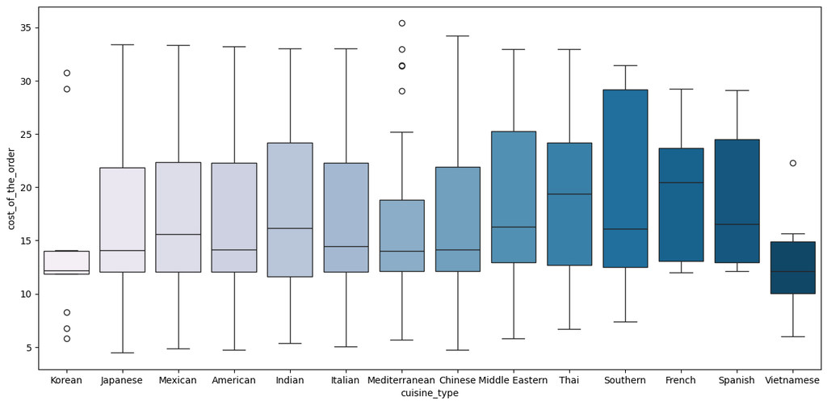

```python
# Write the code here
# cost of the order vs cuisine type
plt.figure(figsize=(15,7))
sns.boxplot(x="cuisine_type", y="cost_of_the_order", data=df, palette='PuBu')
plt.show()
```

##### 2. vietnamese food has the lowest cost and is affordable

##### 3. most cusines have a range of 5 dollar to 35 dollar but they are different in the average order and the outliers

##### 4. korean food has narrower spreading - suggesting a more consistence pricing

#### cusine type vs food preparation time

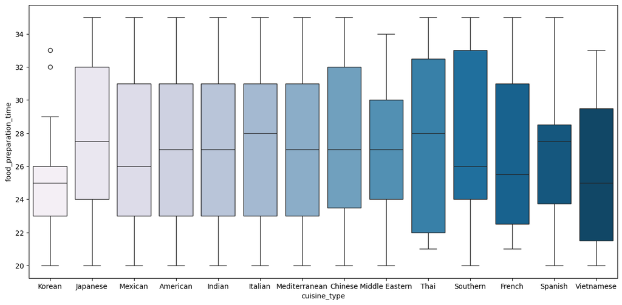

```python
# food preparation time vs cuisine type
plt.figure(figsize=(15,7))
sns.boxplot(x="cuisine_type", y="food_preparation_time", hue="cuisine_type", data=df, palette="PuBu", legend=False)
plt.show()
```

### Observation :

#### most cuisines have preparation time of 20 to 35 minuites

### day of the week vs delivery time

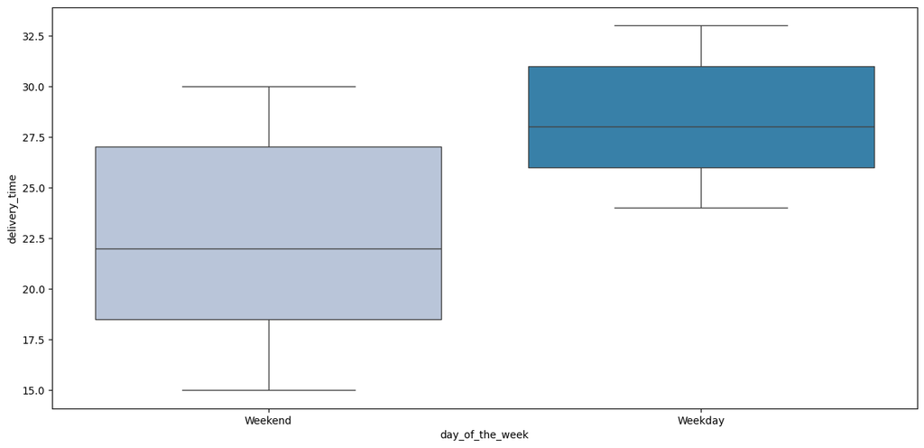

```python
# day of the week vs delivery time
plt.figure(figsize=(15,7))
sns.boxplot(x="day_of_the_week", y="delivery_time", data=df, palette="PuBu")
plt.show()
```

### Observations:

#### weekend deliveries average delivery time is 22 minutes

#### weekday deliveries average is 28 minutes

#### deliveries are faster in the weekend than the weekday possibly due to high trafic or more office hour orders or increased demand

### revenue generated by the restaurants.

```python
# code
df.groupby(['restaurant_name'])['cost_of_the_order'].sum().sort_values(ascending = False).head(14)
```

| restaurant_name | cost_of_the_order |
| --- | --- |
| Shake Shack | 3579.53 |
| The Meatball Shop | 2145.21 |
| Blue Ribbon Sushi | 1903.95 |
| Blue Ribbon Fried Chicken | 1662.29 |
| Parm | 1112.76 |
| RedFarm Broadway | 965.13 |
| RedFarm Hudson | 921.21 |
| TAO | 834.50 |
| Han Dynasty | 755.29 |
| Blue Ribbon Sushi Bar & Grill | 666.62 |
| Rubirosa | 660.45 |
| Sushi of Gari 46 | 640.87 |
| Nobu Next Door | 623.67 |
| Five Guys Burgers and Fries | 506.47 |

**dtype:** float64

### Rating vs Delivery time

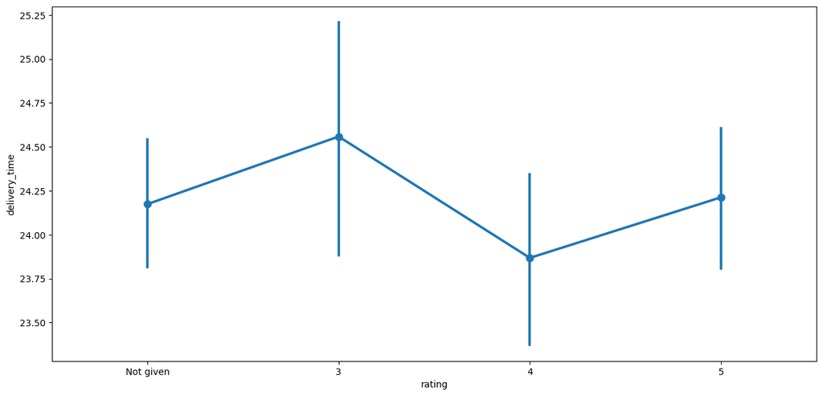

```python
# rating vs delivery time
plt.figure(figsize=(15, 7))
sns.pointplot(x='rating', y='delivery_time', data=df, order=['Not given', '3', '4', '5'])

plt.show()
```

### Observation

#### rating 3 has the highest average delivery time

#### rating 4 has the lowest average delivery time

#### rating 5 and 'Not Given' have average delivery time of 24 minutes

#### all ratings fall withing the 24 and 25 minute range indicating there's no direct impact of delivery time on the ratings given by the customer

### Rating vs Food preparation time

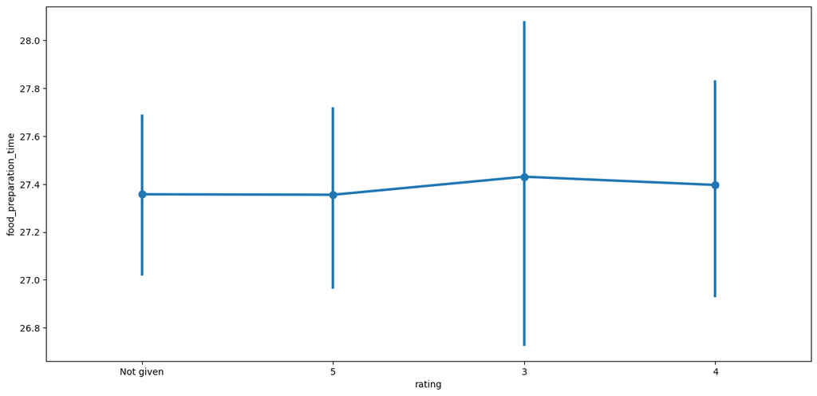

```python
# rating vs food preparation time
plt.figure(figsize=(15, 7))
sns.pointplot(x = 'rating', y = 'food_preparation_time', data = df)
plt.show()
```

### Observation :

#### average preparation time is 27 times

#### food preparation time does not affect the ratings

### Rating vs Cost of the order

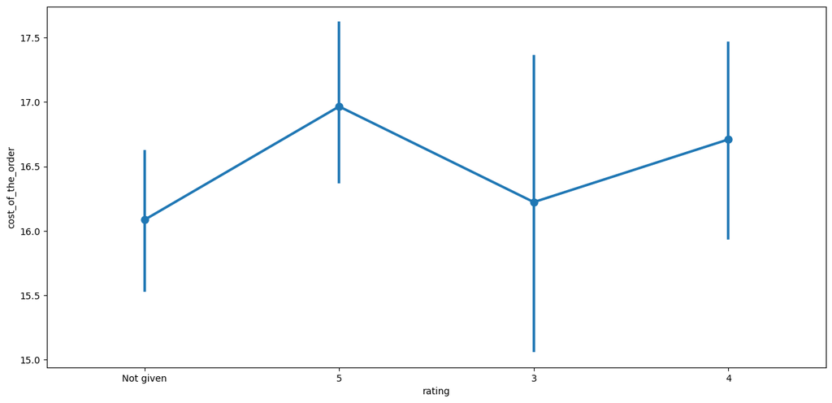

```python
# rating vs cost of the order
plt.figure(figsize=(15, 7))
sns.pointplot(x = 'rating', y = 'cost_of_the_order', data = df)
plt.show()
```

### Correlation among variables

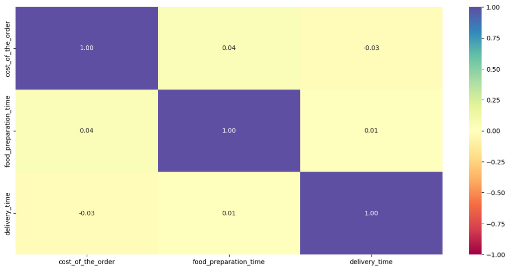

```python
# heat map
col_list = ['cost_of_the_order', 'food_preparation_time', 'delivery_time']
plt.figure(figsize=(15, 7))
sns.heatmap(df[col_list].corr(), annot=True, vmin=-1, vmax=1, fmt=".2f", cmap="Spectral")
plt.show()
```

### Observation :

#### heat map shows very weak relation(close to 0) between variables

### **Question 13:** The company wants to provide a promotional offer in the advertisement of the restaurants. The condition to get the offer is that the restaurants must have a rating count of more than 50 and the average rating should be greater than 4. Find the restaurants fulfilling the criteria to get the promotional offer. [3 marks]

```python
# Write the code here
# Convert rating to numeric, coercing errors (like 's') to NaN
df["rating"] = pd.to_numeric(df["rating"], errors='coerce')

# Drop rows where rating is NaN
df_clean = df.dropna(subset=["rating"])

# Group and filter eligible restaurants
rating_summary = df_clean.groupby("restaurant_name")["rating"].agg(["count", "mean"]).reset_index()

eligible_restaurants = rating_summary[
    (rating_summary["count"] > 50) &
    (rating_summary["mean"] > 4)
].rename(columns={"count": "rating_count", "mean": "average_rating"})

# View result
print(eligible_restaurants)
```

```
               restaurant_name  rating_count  average_rating
16   Blue Ribbon Fried Chicken            64        4.328125
17           Blue Ribbon Sushi            73        4.219178
117                Shake Shack           133        4.278195
132          The Meatball Shop            84        4.511905
```

#### Blue Ribbon Sushi has 73 ratings and a rating of 4.219178

#### Shake Shack has 133 ratings and a rating of 4.278195

#### The Meatball Shop has 84 ratings and a rating of 4.511905

### **Question 14:** The company charges the restaurant 25% on the orders having cost greater than 20 dollars and 15% on the orders having cost greater than 5 dollars. Find the net revenue generated by the company across all orders. [3 marks]

```python
# Write the code here

#calculate revenue
def calculate_revenue(x):
    if x > 20:
        return x*0.25
    elif x > 5:
        return x*0.15
    else:
        return x*0

#apply the 25 and 15 % on all orders cost and store it in new column revenue
df['Revenue'] = df['cost_of_the_order'].apply(calculate_revenue)
df.head()

total_revenue = df['Revenue'].sum() #sum all revenues
print('The net revenue is around', round(total_revenue, 2), 'dollars')
```

```
The net revenue is around 6166.3 dollars
```

#### Observation

#### The net revenue is around 6166.3 dollars

### **Question 15:** The company wants to analyze the total time required to deliver the food. What percentage of orders take more than 60 minutes to get delivered from the time the order is placed? (The food has to be prepared and then delivered.) [2 marks]

```python
# Write the code here
# calculate total tike taken from food preparation and delivery time and store in in a new column named total_time
df['total_time'] = df['food_preparation_time'] + df['delivery_time']

#orders that take more than 60 min
orders_more_than_60_min = df[df['total_time'] > 60]

#calculate percentage
percentage = (len(orders_more_than_60_min) / len(df)) * 100
print(round(percentage,0), '%')
```

```
11.0 %
```

#### Observations:

#### percentage of orders that take more than 6 minutes 11.0 %

### **Question 16:** The company wants to analyze the delivery time of the orders on weekdays and weekends. How does the mean delivery time vary during weekdays and weekends? [2 marks]

```python
# Write the code here
# average delivery time on weekdays
print('The mean delivery time on weekdays is around',
      round(df[df['day_of_the_week'] == 'Weekday']['delivery_time'].mean()),
     'minutes')

## average delivery time on weekends
print('The mean delivery time on weekends is around',
      round(df[df['day_of_the_week'] == 'Weekend']['delivery_time'].mean()),
     'minutes')
```

```
The mean delivery time on weekdays is around 28 minutes
The mean delivery time on weekends is around 22 minutes
```

```python
!jupyter nbconvert --to html '/content/drive/My Drive/Colab Notebooks/Full-Code-version'
```

```
[NbConvertApp] Converting notebook /content/drive/My Drive/Colab Notebooks/Full-Code-version to html
[NbConvertApp] WARNING | Alternative text is missing on 13 image(s).
[NbConvertApp] Writing 877688 bytes to /content/drive/My Drive/Colab Notebooks/Full-Code-versio.html
```